# Distribuições de Probabilidade e Hidrologia

## Distribuições de probabilidade na Hidrologia

Na hidrologia, os possiveis usos das distribuições de probabilidade são extensos. Alguns usos comuns são: estimar médias anuais de chuvas para determinados locais; estimar recorrências de grandes valores de chuvas e estimar vazões de referências.

Nesta primeira postagem serão apresentadas algumas aplicações de distribuições de probabilidade para caracterizar valores esperados de chuva, a exemplo de valores médios e recorrências de grandes volumes precipitados.

Nesta aventura teremos nosso grande amigo R!

## Um pouco sobre distribuições de probabilidade

A distribuição de probabilidade de uma dada variável aleátoria descreve como estas probabilidades são distribruidas ao longo dos valores desta variável. Neste caso, é preciso primariamente, definir se tratamos de uma variável aleatória discreta ou contínua.

Ao se tratar de uma variável aleatória discreta, a distribuição de probabilidade é definida por uma função de probabilidade denominada de f(x). Esta função provém um valor de probabilidade para cada um dos valores da variável discreta.

Por outro lado, ao se falar de uma variável aleatória contínua faz mais sentido encontrar a probabilidade de que uma dada observação esteja contida em um intervalo de valores.

Para se aprofundar neste tema é indicado que se leia: “Applied Statistics and Probability for Engineers”: Montgomery e Runger.

## Obtenção dos dados

Para obter os dados usaremos o pacote inmetr que funciona como um API para busca e download dos dados provenientes do Instituto Nacional de Metereologia. Também, incluiremos nosso fiel companheiro “Tidyverse”.

```r
library(devtools)
install_github('lhmet/inmetr')
library(inmetr)
library(tidyverse)
library(lubridate)
library(broom)
```

Para obter os dados devemos escolher uma determinada estação pluviométrica, escolheremos Alagoinhas por ser minha terra de origem. E por que lá existe vampiros.

```r
stations <- c("Alagoinhas")
stations_rows <- pmatch(stations, bdmep_meta$name)  #busca a estação
stns_codes <- bdmep_meta[stations_rows, "id"]       # retorna o id

stns_codes
```

```
## [1] "83249"
```

Faremos então o downloads dos dados:

```r
start_date <- "01/01/1961"
end_date <- format(Sys.Date(), "%d/%m/%Y")
data <- bdmep_import(id = stns_codes,
                         sdate = start_date,
                         edate = end_date,
                         email = "your-email",
                         passwd = "your-password",
                         verbose = TRUE)
```

```
## # A tibble: 6 x 18
##   date                id     prec  tair    tw  tmax  tmin urmax  patm
##   <dttm>              <chr> <dbl> <dbl> <dbl> <dbl> <dbl> <dbl> <dbl>
## 1 1988-01-01 00:00:00 83249    NA  25.2  22.8  40.2  NA      82  996.
## 2 1988-01-01 12:00:00 83249     0  29    23.5  NA    22      63  996.
## 3 1988-01-01 18:00:00 83249    NA  36.9  24.4  NA    NA      36  991
## 4 1988-01-02 00:00:00 83249    NA  26.4  24.2  37.7  NA      83  994.
## 5 1988-01-02 12:00:00 83249     0  30.9  24.2  NA    24.6    58  996.
## 6 1988-01-02 18:00:00 83249    NA  36.6  24.3  NA    NA      37  990.
## # ... with 9 more variables: pnmm <dbl>, wd <dbl>, wsmax <dbl>, n <dbl>,
## #   cc <dbl>, evap <dbl>, ur <dbl>, ws <dbl>, request_status <chr>
```

E usaremos as funções do Tidyverse para filtrar apenas os valores de chuva:

```r
met_data <- met_data %>%
  select(date, prec) %>%
  na.omit()

head(met_data)
```

```
## # A tibble: 6 x 2
##   date                 prec
##   <dttm>              <dbl>
## 1 1988-01-01 12:00:00     0
## 2 1988-01-02 12:00:00     0
## 3 1988-01-03 12:00:00     0
## 4 1988-01-04 12:00:00     0
## 5 1988-01-05 12:00:00     0
## 6 1988-01-06 12:00:00     0
```

### Primeira distribuição: Distribuição dos totais anuais

Para isto vamos agrupar o banco de dados de forma anual e criar um novo onde as observações corresponderam a soma das chuvas observadas anualmente:

```r
met_anual <- met_data %>%
  mutate(year = year(date)) %>%
  group_by(year) %>%
  summarise(prec = sum(prec)) %>%
  glimpse()
```

```
## Observations: 30
## Variables: 2
## $ year <dbl> 1988, 1989, 1990, 1992, 1993, 1994, 1995, 1996, 1997, 199...
## $ prec <dbl> 1381.7, 168.9, 0.0, 1100.7, 681.4, 827.2, 843.2, 1172.0, ...
```

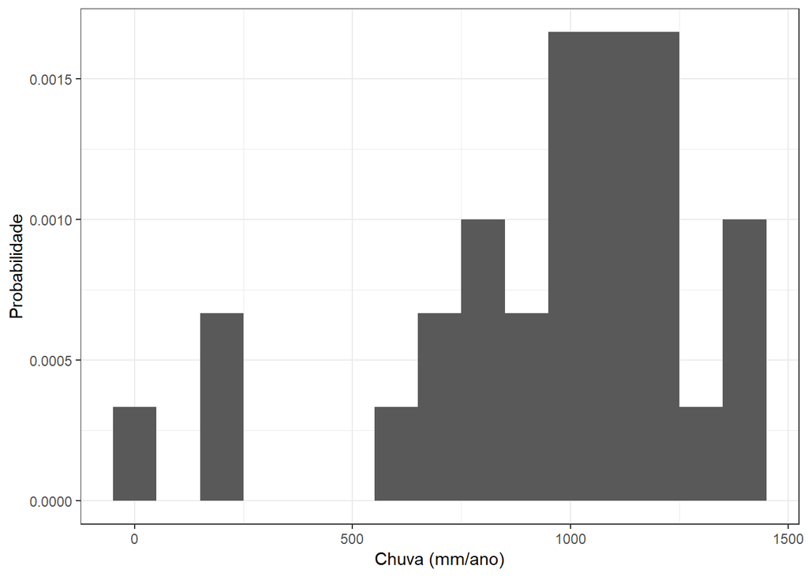

```r
met_data %>%
  mutate(year = year(date)) %>%
  group_by(year) %>%
  summarise(prec = sum(prec)) %>%
  ggplot(aes(x = prec, y = ..density..)) +
  geom_histogram(binwidth = 100) +
  theme_bw() +
  labs(x = "Chuva (mm/ano)", y = "Probabilidade")
```

# Modelando a distribuição de probabilidade

[figure not shown]

Chegamos enfim, a modelagem propriamente dita. Testaremos a princípio as distribuições: Normal, Gamma e Exponencial

```r
MASS::fitdistr(met_anual$prec, "normal") %>%
  glance()
```

```
##    n    logLik      AIC    BIC
## 1 30 -217.5388 439.0776 441.88
```

```r
MASS::fitdistr(met_anual$prec+0.01, "gamma") %>%
  glance()
```

```
##    n   logLik     AIC      BIC
## 1 30 -235.234 474.468 477.2704
```

```r
MASS::fitdistr(met_anual$prec+0.01, "exponential") %>%
  glance()
```

```
##    n    logLik      AIC      BIC
## 1 30 -235.8951 473.7902 475.1914
```

Testando se realmente temos uma distribuição normal pelo teste de Shapiro-Wilker:

```r
shapiro.test(met_anual$prec)
```

```
##
##  Shapiro-Wilk normality test
##
## data:  met_anual$prec
## W = 0.89258, p-value = 0.005556
```

Apesar de ser o modelo de distribuição de probabilidade que apresentou melhores resultados frente ao AIC, a hipótese de que a distribuição de probabilidade em questão se tratava de uma distribuição normal foi rejeitada pelo teste de Shapiro-Wilker.

Visto isto, pode-se pensar em métodos, por exemplo, que encontrem [change-points](https://www.ncbi.nlm.nih.gov/pmc/articles/PMC5464762/) na série temporal em questão, agrupando-a de forma a obter distribuições de probabilidades homogêneas para determinados intervalos de tempo.